# Sports Betting on Unemployment

Kevin Phan

2025-05-10

# Analysis

I create the analysis dataframe that is fundamental to all the models and summary statistics that I will do.

```r
## modifying the unemployment rate and the bachelor's degrees rate
# adding in the time-to-treatment variable.
# nevada's retail vs sports implementation too extreme based on calculation

df_analysis <- df %>%
  filter(!(state == "Nevada"), date > 2015) %>%
  mutate(unemployment = unemployment/100,
         bachelors = bachelors/100,
         Poverty.Rate = Poverty.Rate/100,
         time_treat_retail = ifelse(retail == 1, date - retailyear, 0),
         time_treat_online = ifelse(online == 1, date - onlineyear, 0),
         time_treat = ifelse(legal == 1, date - legal.year, 0))
```

# Summary Statistics

## Basic Summary 1: Ungrouped

```r
summary <- df_analysis %>% select(population, unemployment, bachelors, rgdp_2017, Employment, Poverty.Rate)
labels = c("Population (Thou)",
           "Unemployment Rate (%)", # must adjust in latex to avoid commenting issue.
           "Bachelor's Degree (% of Population)",
           "Real GDP (2017, Thou)",
           "Employment (Thou)", #not seasonally adjusted, reason in caption...
           "Poverty Rate (%)")

table1_tex <- capture.output(stargazer(summary, type = "latex", float.env = "sidewaystable", title = "Descriptive Statistics of All States", digits = 1, covariate.labels = labels, notes = "Employment is not seasonally adjusted, chosen due to the nature of the sports industry."))

# table1_tex <- gsub("\\\\centering", "\\\\raggedright", table1_tex) # not necessary for sideways tables...
cat(table1_tex, sep = "\n")
```

```
##
## % Table created by stargazer v.5.2.3 by Marek Hlavac, Social Policy Institute. E-mail: marek.hlavac at gmail.com
## % Date and time: Mon, Sep 29, 2025 - 22:27:24
## % Requires LaTeX packages: rotating
## \begin{sidewaystable}[!htbp] \centering
##   \caption{Descriptive Statistics of All States}
##   \label{}
## \begin{tabular}{@{\extracolsep{5pt}}lccccc}
## \\[-1.8ex]\hline
## \hline \\[-1.8ex]
## Statistic & \multicolumn{1}{c}{N} & \multicolumn{1}{c}{Mean} & \multicolumn{1}{c}{St. Dev.} & \multicolumn{1}{c}{Min} & \multicolumn{1}{c}{Max} \\
## \hline \\[-1.8ex]
## Population (Thou) & 392 & 6,652.3 & 7,392.7 & 577.7 & 39,522.0 \\
## Unemployment Rate (%) & 392 & 0.04 & 0.02 & 0.02 & 0.1 \\
## Bachelor's Degree (% of Population) & 392 & 0.3 & 0.1 & 0.2 & 0.5 \\
## Real GDP (2017, Thou) & 392 & 414,852.5 & 528,114.9 & 32,252.7 & 3,248,656.0 \\
## Employment (Thou) & 392 & 3,117.9 & 3,406.6 & 275.6 & 18,627.4 \\
## Poverty Rate (%) & 392 & 0.1 & 0.03 & 0.04 & 0.2 \\
## \hline \\[-1.8ex]
## \multicolumn{6}{l}{Employment is not seasonally adjusted, chosen due to the nature of the sports industry.} \\
## \end{tabular}
## \end{sidewaystable}
```

## Basic Summary 2: Grouped by Legal, Retail Only, Online Only

The idea is to concatenate this table with the first table to make a very large table. This is done in LaTeX.

```r
summary_retail <- df_analysis %>% filter(retail == 1) %>% select(population, unemployment, bachelors, rgdp_2017, Employment, Poverty.Rate)

table1_ret_tex <- capture.output(stargazer(summary_retail, type = "latex", title = "Descriptive Statistics (States Legalized Retail)", digits = 1, covariate.labels = labels))

summary_online <- df_analysis %>% filter(online == 1) %>% select(population, unemployment, bachelors, rgdp_2017, Employment, Poverty.Rate)

table1_onl_tex <- capture.output(stargazer(summary_online, type = "latex", title = "Descriptive Statistics (States Legalized Online)", digits = 1, covariate.labels = labels, notes = "Many states that have legalized online gambling have also legalized retail gambling (and vice versa). This explains why the number of observations between the second table and third table are seemingly too high."))

cat(table1_ret_tex, table1_onl_tex, sep = '\n')
```

```
##
## % Table created by stargazer v.5.2.3 by Marek Hlavac, Social Policy Institute. E-mail: marek.hlavac at gmail.com
## % Date and time: Mon, Sep 29, 2025 - 22:27:24
## \begin{table}[!htbp] \centering
##   \caption{Descriptive Statistics (States Legalized Retail)}
##   \label{}
## \begin{tabular}{@{\extracolsep{5pt}}lccccc}
## \\[-1.8ex]\hline
## \hline \\[-1.8ex]
## Statistic & \multicolumn{1}{c}{N} & \multicolumn{1}{c}{Mean} & \multicolumn{1}{c}{St. Dev.} & \multicolumn{1}{c}{Min} & \multicolumn{1}{c}{Max} \\
## \hline \\[-1.8ex]
## Population (Thou) & 280 & 5,889.5 & 5,118.1 & 577.7 & 22,904.9 \\
## Unemployment Rate (%) & 280 & 0.04 & 0.02 & 0.02 & 0.1 \\
## Bachelor's Degree (% of Population) & 280 & 0.3 & 0.1 & 0.2 & 0.5 \\
## Real GDP (2017, Thou) & 280 & 364,049.5 & 350,960.2 & 36,198.2 & 1,791,211.0 \\
## Employment (Thou) & 280 & 2,781.4 & 2,373.4 & 275.6 & 10,668.9 \\
## Poverty Rate (%) & 280 & 0.1 & 0.03 & 0.04 & 0.2 \\
## \hline \\[-1.8ex]
## \end{tabular}
## \end{table}
##
## % Table created by stargazer v.5.2.3 by Marek Hlavac, Social Policy Institute. E-mail: marek.hlavac at gmail.com
## % Date and time: Mon, Sep 29, 2025 - 22:27:24
## \begin{table}[!htbp] \centering
##   \caption{Descriptive Statistics (States Legalized Online)}
##   \label{}
## \begin{tabular}{@{\extracolsep{5pt}}lccccc}
## \\[-1.8ex]\hline
## \hline \\[-1.8ex]
## Statistic & \multicolumn{1}{c}{N} & \multicolumn{1}{c}{Mean} & \multicolumn{1}{c}{St. Dev.} & \multicolumn{1}{c}{Min} & \multicolumn{1}{c}{Max} \\
## \hline \\[-1.8ex]
## Population (Thou) & 232 & 6,565.9 & 5,306.7 & 577.7 & 22,904.9 \\
## Unemployment Rate (%) & 232 & 0.04 & 0.02 & 0.02 & 0.1 \\
## Bachelor's Degree (% of Population) & 232 & 0.3 & 0.1 & 0.2 & 0.5 \\
## Real GDP (2017, Thou) & 232 & 404,478.7 & 364,072.2 & 32,252.7 & 1,791,211.0 \\
## Employment (Thou) & 232 & 3,093.3 & 2,451.0 & 275.6 & 10,668.9 \\
## Poverty Rate (%) & 232 & 0.1 & 0.03 & 0.04 & 0.2 \\
## \hline \\[-1.8ex]
## \multicolumn{6}{l}{Many states that have legalized online gambling have also legalized retail gambling (and vice versa). This explains why the number of observations between the second table and third table are seemingly too high.} \\
## \end{tabular}
## \end{table}
```

#Plot of US Map with Legalization

This is quite straightforward so I won’t elaborate much further.

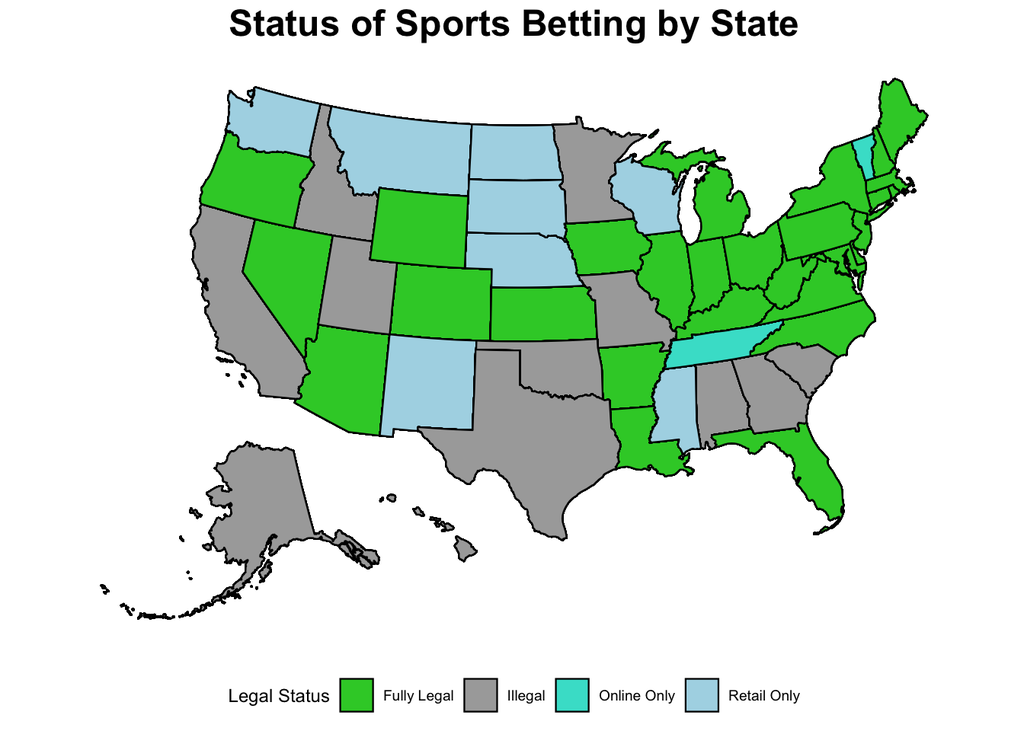

```r
library(usmap)
# must plot the states that are fully, those that are partially, and those that are not legalized

df_plot <- df %>%
  mutate(legal_status = case_when(
    (retail == 1 & online == 1) ~ 'Fully Legal',
    (retail == 1 & online == 0) ~ 'Retail Only',
    (online == 1 & retail == 0) ~ 'Online Only',
    TRUE ~ 'Illegal'
  ))
plot_usmap(color = "black",
           regions = "states",
           data = df_plot,
           values = "legal_status") + labs(
             fill = "Legal Status"
           ) + theme(legend.position = 'bottom', plot.title = element_text(hjust = .5, size = 18, face = "bold")) + scale_fill_manual(values = c("Fully Legal" = "limegreen", "Retail Only" = "lightblue", "Online Only" = "turquoise", "Illegal" = "darkgrey"), na.translate = FALSE) +
  ggtitle("Status of Sports Betting by State")
```

# Trend of Legalization

Uses panelView package to achieve this, better looking than a simple line or bar plot.

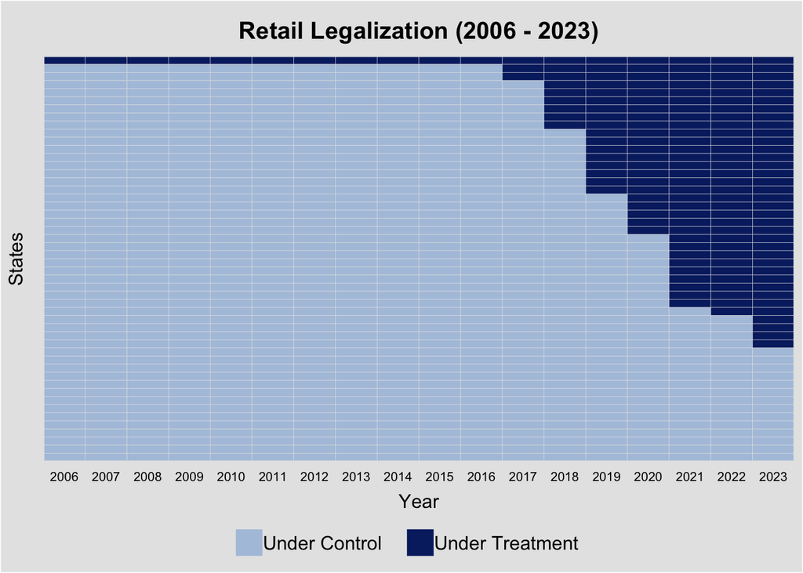

```r
library(panelView)
# i need to create a separate variable for implementation years only
df_special <- df %>%
  arrange(state, date) %>%
  mutate(implementation_retail = replace_na(if_else(date >= retailyear, 1, 0),0),
         implementation_online = replace_na(if_else(date >= onlineyear, 1, 0),0))


panelview(unemployment ~ implementation_retail, data = df_special, index = c("abbrev","date"),  xlab = "Year", ylab = "States", main = "Retail Legalization (2006 - 2023)", display.all = T, axis.lab = "time",
  gridOff = FALSE, by.timing = TRUE)
```

```r
panelview(data = df_special,Y='unemployment',
          D='implementation_retail',index=c("abbrev","year"),
          by.timing = TRUE, display.all = TRUE,
          xlab = "Year", ylab = "Unemployment Rate", main = "Unemployment Rate based on Retail Legalization (2006 - 2023)", xlim = c(2006, 2023), ylim = c(0,15),
          type = "outcome", by.cohort = TRUE)
```

```
## Number of unique treatment histories: 9
```

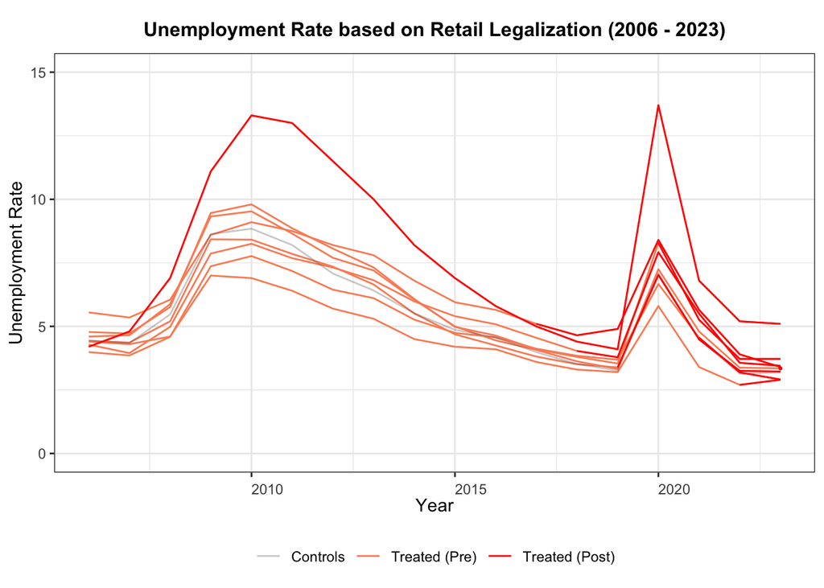

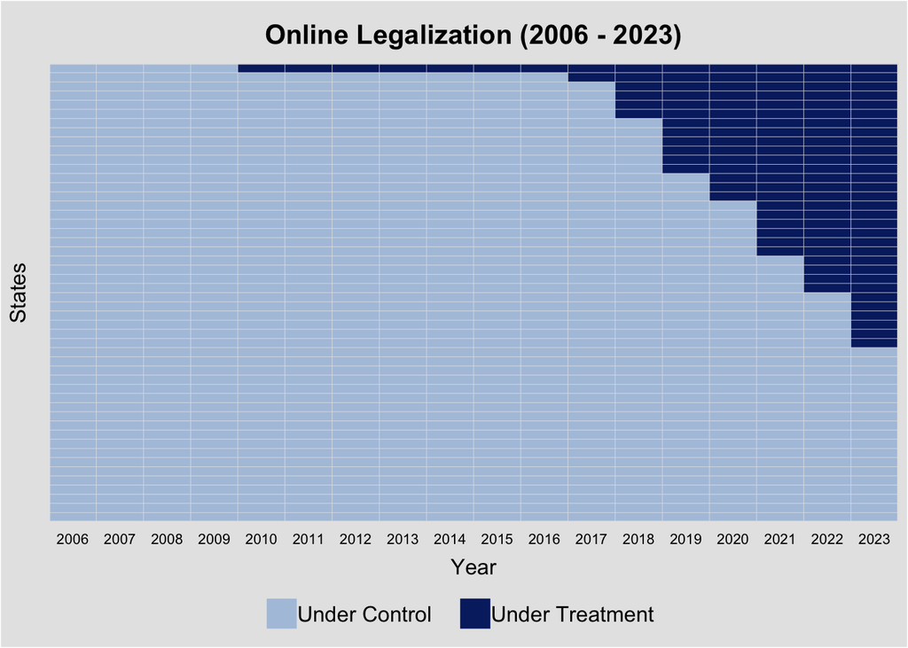

```r
panelview(unemployment ~ implementation_online, data = df_special, index = c("abbrev","date"),  xlab = "Year", ylab = "States", main = "Online Legalization (2006 - 2023)", axis.lab = "time", display.all = T,
  gridOff = FALSE, by.timing = TRUE)
```

```r
panelview(data = df_special,Y='unemployment',
          D='implementation_online',index=c("abbrev","year"),
          by.timing = TRUE, display.all = TRUE,
          xlab = "Year", ylab = "Unemployment Rate", main = "Unemployment Rate based on Online Legalization (2006 - 2023)", axis.lab.gap = 2, ylim = c(0,15),
          type = "outcome", by.cohort = TRUE)
```

```
## Number of unique treatment histories: 9
```

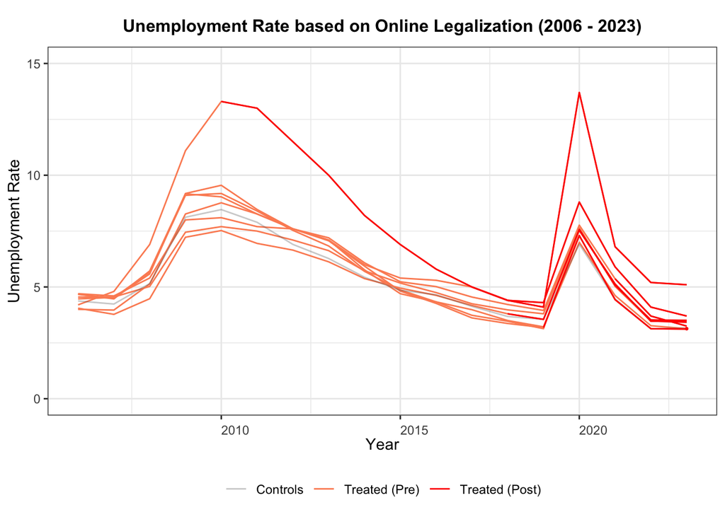

[output not shown]

# Trends in Legalization

Plot that shows the freq of legalization. Not particularly useful.

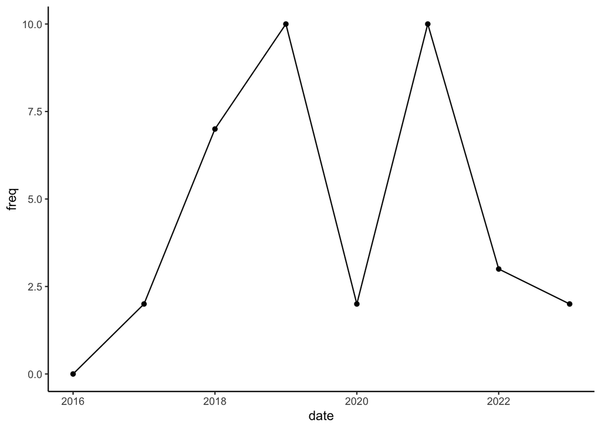

# Pre-Trends Testing

This is somewhat useless, but interesting to look at. The pre-trends inspection is something we can do when we estimate the models after all.

```
## NOTE: 2/0 fixed-effect singletons were removed (2 observations).
```

```
## The variable 'time_treat_retail::-1:retailyear' has been removed because of
## collinearity (see $collin.var).
```

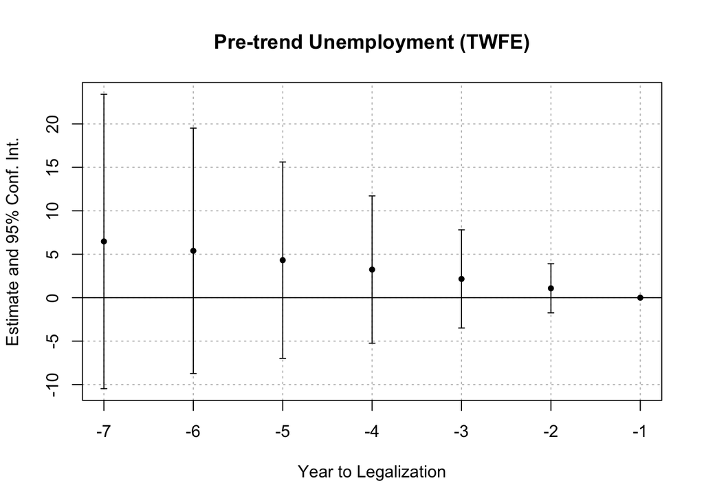

```
## OLS estimation, Dep. Var.: unemployment
## Observations: 135
## Fixed-effects: abbrev: 33,  date: 7
## Standard-errors: Clustered (abbrev)
##                                       Estimate Std. Error   t value   Pr(>|t|)
## time_treat_retail::-7:retailyear  6.4743354276 8.31478559  0.778653 4.4190e-01
## time_treat_retail::-6:retailyear  5.3966134070 6.93070193  0.778653 4.4190e-01
## time_treat_retail::-5:retailyear  4.3183573174 5.54593255  0.778653 4.4190e-01
## time_treat_retail::-4:retailyear  3.2395696176 4.16047848  0.778653 4.4190e-01
## time_treat_retail::-3:retailyear  2.1602477792 2.77433921  0.778653 4.4190e-01
## time_treat_retail::-2:retailyear  1.0803911621 1.38751297  0.778653 4.4190e-01
## population                        0.0000047964 0.00000896  0.535139 5.9625e-01
## rgdp_2017                        -0.0000000663 0.00000100 -0.066231 9.4761e-01
## bachelors                         0.4047690544 0.06007272  6.737984 1.3053e-07
##
## time_treat_retail::-7:retailyear
## time_treat_retail::-6:retailyear
## time_treat_retail::-5:retailyear
## time_treat_retail::-4:retailyear
## time_treat_retail::-3:retailyear
## time_treat_retail::-2:retailyear
## population
## rgdp_2017
## bachelors                        ***
## ... 1 variable was removed because of collinearity
## (time_treat_retail::-1:retailyear)
## ---
## Signif. codes:  0 '***' 0.001 '**' 0.01 '*' 0.05 '.' 0.1 ' ' 1
## RMSE: 0.003466     Adj. R2: 0.887885
##                  Within R2: 0.280219
```

```
## NOTE: 1/0 fixed-effect singleton was removed (1 observation).
```

```
## The variable 'time_treat_online::-1:onlineyear' has been removed because of
## collinearity (see $collin.var).
```

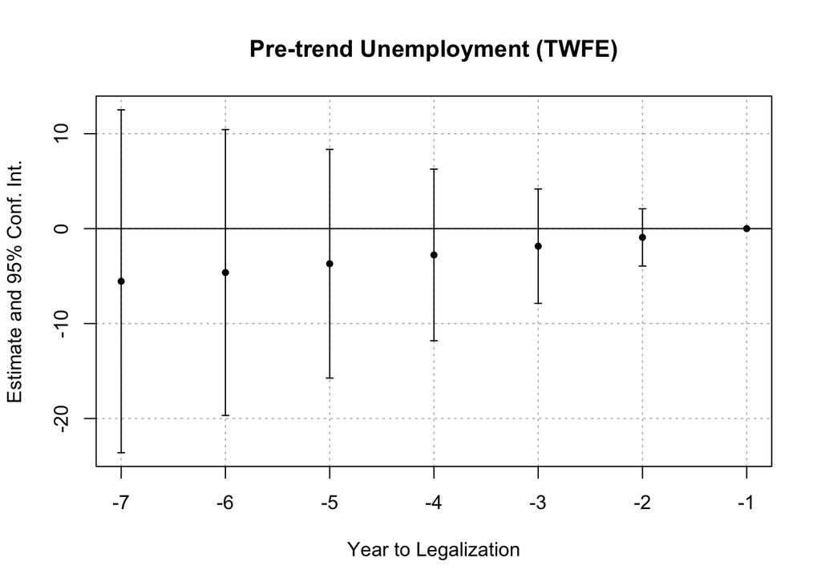

```
## OLS estimation, Dep. Var.: unemployment
## Observations: 132
## Fixed-effects: abbrev: 28,  date: 7
## Standard-errors: Clustered (abbrev)
##                                       Estimate Std. Error   t value Pr(>|t|)
## time_treat_online::-7:onlineyear -5.5465575763 8.80154891 -0.630180 0.533875
## time_treat_online::-6:onlineyear -4.6232751187 7.33643836 -0.630180 0.533875
## time_treat_online::-5:onlineyear -3.6995351164 5.87060194 -0.630180 0.533874
## time_treat_online::-4:onlineyear -2.7753374304 4.40404061 -0.630180 0.533875
## time_treat_online::-3:onlineyear -1.8506827288 2.93675398 -0.630180 0.533875
## time_treat_online::-2:onlineyear -0.9255706409 1.46874037 -0.630180 0.533874
## population                        0.0000108522 0.00000727  1.492152 0.147253
## rgdp_2017                        -0.0000000544 0.00000100 -0.054398 0.957019
## bachelors                         0.2957057928 0.12069757  2.449973 0.021054
##
## time_treat_online::-7:onlineyear
## time_treat_online::-6:onlineyear
## time_treat_online::-5:onlineyear
## time_treat_online::-4:onlineyear
## time_treat_online::-3:onlineyear
## time_treat_online::-2:onlineyear
## population
## rgdp_2017
## bachelors                        *
## ... 1 variable was removed because of collinearity
## (time_treat_online::-1:onlineyear)
## ---
## Signif. codes:  0 '***' 0.001 '**' 0.01 '*' 0.05 '.' 0.1 ' ' 1
## RMSE: 0.004364     Adj. R2: 0.871211
##                  Within R2: 0.131114
```

# TWFE model & SA model

The models as well as their tables/figures. Focus on the results from Sun and Abraham. The TWFE models are there to demonstrate bias in the method, hence why Sun and Abraham is crucial.

```r
model_twfe1 <- feols(unemployment ~ i(time_treat_retail, retail, ref = -1) +
                      population + rgdp_2017 + bachelors + Poverty.Rate + Federal.Minimum.Wage| abbrev + date,
                    cluster = ~ abbrev,
                    data = df_analysis)
```

```
## The variable 'Federal.Minimum.Wage' has been removed because of collinearity
## (see $collin.var).
```

```r
summary(model_twfe1)
```

```
## OLS estimation, Dep. Var.: unemployment
## Observations: 392
## Fixed-effects: abbrev: 49,  date: 8
## Standard-errors: Clustered (abbrev)
##                                   Estimate Std. Error   t value   Pr(>|t|)
## time_treat_retail::-7:retail  8.350449e-04 0.00458344  0.182188 8.5620e-01
## time_treat_retail::-6:retail  8.138052e-04 0.00345223  0.235733 8.1464e-01
## time_treat_retail::-5:retail  1.438630e-04 0.00238384  0.060349 9.5213e-01
## time_treat_retail::-4:retail  5.725690e-04 0.00215128  0.266153 7.9126e-01
## time_treat_retail::-3:retail  1.030486e-03 0.00197026  0.523020 6.0337e-01
## time_treat_retail::-2:retail  1.062774e-03 0.00129115  0.823123 4.1451e-01
## time_treat_retail::0:retail   2.975862e-03 0.00122194  2.435364 1.8642e-02 *
## time_treat_retail::1:retail   2.496751e-03 0.00185814  1.343681 1.8537e-01
## time_treat_retail::2:retail   2.263230e-03 0.00215458  1.050426 2.9878e-01
## time_treat_retail::3:retail   4.254613e-03 0.00231819  1.835321 7.2658e-02 .
## time_treat_retail::4:retail   2.571890e-03 0.00262054  0.981436 3.3130e-01
## time_treat_retail::5:retail  -2.777726e-04 0.00346772 -0.080102 9.3649e-01
## time_treat_retail::6:retail  -5.069614e-03 0.00379565 -1.335638 1.8797e-01
## population                    4.592600e-07 0.00000311  0.147789 8.8313e-01
## rgdp_2017                     7.400000e-09 0.00000100  0.007398 9.9413e-01
## bachelors                     2.298353e-01 0.05008529  4.588878 3.2184e-05 ***
## Poverty.Rate                  3.806660e-02 0.03865237  0.984845 3.2964e-01
## ... 1 variable was removed because of collinearity
## (Federal.Minimum.Wage)
## ---
## Signif. codes:  0 '***' 0.001 '**' 0.01 '*' 0.05 '.' 0.1 ' ' 1
## RMSE: 0.005538     Adj. R2: 0.851619
##                  Within R2: 0.086455
```

```r
model_sa1 <- feols(unemployment ~ sunab(retailyear, date) +
                      population + rgdp_2017 + bachelors + Poverty.Rate + Federal.Minimum.Wage | abbrev + date,
                    cluster = ~ abbrev,
                    data = df_analysis)
```

```
## NOTE: 112 observations removed because of NA values (RHS: 112).
```

```
## The variables 'date::3:cohort::2017', 'date::3:cohort::2020',
## 'date::4:cohort::2017', 'date::4:cohort::2019', 'date::5:cohort::2017',
## 'date::5:cohort::2018' and 2 others have been removed because of collinearity
## (see $collin.var).
```

```r
summary(model_sa1)
```

```
## OLS estimation, Dep. Var.: unemployment
## Observations: 280
## Fixed-effects: abbrev: 35,  date: 8
## Standard-errors: Clustered (abbrev)
##                   Estimate Std. Error   t value   Pr(>|t|)
## date::-7     -0.0043336736 0.00556166 -0.779205 0.44124922
## date::-6     -0.0002333455 0.00399166 -0.058458 0.95372590
## date::-5      0.0048686855 0.00272683  1.785474 0.08310776 .
## date::-4      0.0028470242 0.00237716  1.197657 0.23933372
## date::-3     -0.0003473235 0.00196708 -0.176568 0.86089539
## date::-2      0.0019687332 0.00121326  1.622680 0.11389529
## date::0       0.0035641429 0.00086714  4.110241 0.00023582 ***
## date::1       0.0013711178 0.00141855  0.966562 0.34058829
## date::2       0.0006003235 0.00133704  0.448996 0.65628357
## date::3      -0.0023386009 0.00246659 -0.948112 0.34976296
## date::4      -0.0035670107 0.00239113 -1.491771 0.14498035
## population    0.0000127425 0.00000597  2.135285 0.04002591 *
## rgdp_2017    -0.0000000919 0.00000100 -0.091847 0.92735893
## bachelors     0.2492095243 0.06158485  4.046605 0.00028327 ***
## Poverty.Rate  0.0048466679 0.02809435  0.172514 0.86405632
## ... 8 variables were removed because of collinearity
## (date::3:cohort::2017, date::3:cohort::2020 and 6 others [full set in
## $collin.var])
## ---
## Signif. codes:  0 '***' 0.001 '**' 0.01 '*' 0.05 '.' 0.1 ' ' 1
## RMSE: 0.004316     Adj. R2: 0.889812
##                  Within R2: 0.297965
```

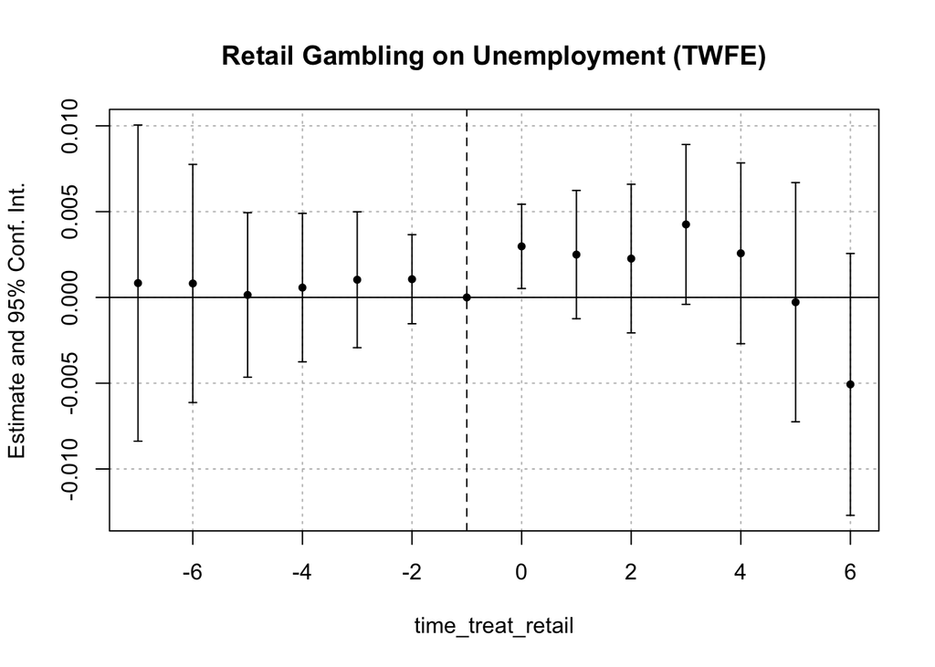

```r
iplot(model_twfe1, main = "Retail Gambling on Unemployment (TWFE)")
```

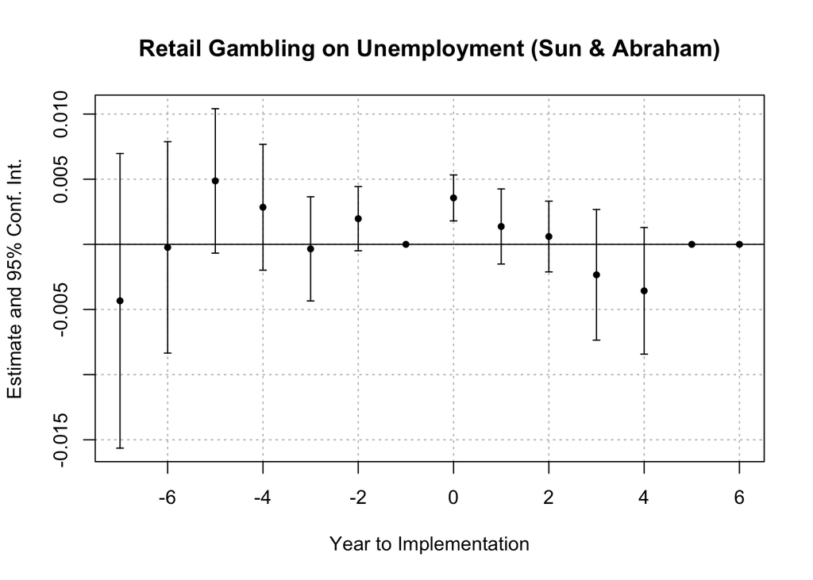

```r
iplot(model_sa1, main = "Retail Gambling on Unemployment (Sun & Abraham)", xlab = "Year to Implementation")
```

```r
model_twfe2 <- feols(unemployment ~ i(time_treat_online, online, ref = -1) +
                      population + rgdp_2017 + bachelors + Poverty.Rate + Federal.Minimum.Wage | abbrev + date,
                    cluster = ~ abbrev,
                    data = df_analysis)
```

```
## The variable 'Federal.Minimum.Wage' has been removed because of collinearity
## (see $collin.var).
```

```r
model_sa2 <- feols(unemployment ~ sunab(onlineyear, date) +
                      population + rgdp_2017 + bachelors + Poverty.Rate + Federal.Minimum.Wage | abbrev + date,
                    cluster = ~ abbrev,
                    data = df_analysis)
```

```
## NOTE: 153 observations removed because of NA values (RHS: 153).
```

```
## The variable 'Federal.Minimum.Wage' has been removed because of collinearity
## (see $collin.var).
```

```r
summary(model_twfe2)
```

```
## OLS estimation, Dep. Var.: unemployment
## Observations: 392
## Fixed-effects: abbrev: 49,  date: 8
## Standard-errors: Clustered (abbrev)
##                                   Estimate Std. Error   t value   Pr(>|t|)
## time_treat_online::-7:online  4.254834e-04 0.00373455  0.113932 0.90976714
## time_treat_online::-6:online -6.986616e-04 0.00289082 -0.241683 0.81005530
## time_treat_online::-5:online -1.337106e-03 0.00225881 -0.591953 0.55666035
## time_treat_online::-4:online -9.498827e-04 0.00205820 -0.461512 0.64651586
## time_treat_online::-3:online -7.900838e-04 0.00205588 -0.384305 0.70245005
## time_treat_online::-2:online -6.576040e-04 0.00127316 -0.516512 0.60786871
## time_treat_online::0:online   1.298973e-03 0.00135537  0.958387 0.34267029
## time_treat_online::1:online   2.193769e-03 0.00182416  1.202621 0.23502191
## time_treat_online::2:online   1.206394e-03 0.00182706  0.660294 0.51222158
## time_treat_online::3:online   3.286937e-03 0.00240502  1.366701 0.17808676
## time_treat_online::4:online   2.944414e-03 0.00245442  1.199638 0.23616801
## time_treat_online::5:online   2.855817e-03 0.00230516  1.238880 0.22141400
## time_treat_online::6:online  -1.583287e-03 0.00236695 -0.668914 0.50675501
## population                    7.673900e-07 0.00000299  0.256703 0.79850546
## rgdp_2017                     8.350000e-09 0.00000100  0.008347 0.99337463
## bachelors                     2.219710e-01 0.05476030  4.053503 0.00018398 ***
## Poverty.Rate                  3.664532e-02 0.03767707  0.972616 0.33562021
## ... 1 variable was removed because of collinearity
## (Federal.Minimum.Wage)
## ---
## Signif. codes:  0 '***' 0.001 '**' 0.01 '*' 0.05 '.' 0.1 ' ' 1
## RMSE: 0.005582     Adj. R2: 0.849255
##                  Within R2: 0.0719
```

```r
summary(model_sa2)
```

```
## OLS estimation, Dep. Var.: unemployment
## Observations: 239
## Fixed-effects: abbrev: 30,  date: 8
## Standard-errors: Clustered (abbrev)
##                   Estimate Std. Error   t value  Pr(>|t|)
## date::-7      0.0011031405 0.00374502  0.294562 0.7704266
## date::-6     -0.0018165794 0.00291577 -0.623018 0.5381416
## date::-5      0.0004709477 0.00258952  0.181867 0.8569523
## date::-4      0.0003638515 0.00214441  0.169674 0.8664444
## date::-3     -0.0004420559 0.00212159 -0.208361 0.8364040
## date::-2     -0.0007916064 0.00120800 -0.655304 0.5174370
## date::0       0.0018812423 0.00123735  1.520382 0.1392443
## date::1       0.0032704123 0.00177826  1.839105 0.0761597 .
## date::2       0.0022205025 0.00173846  1.277279 0.2116356
## date::3       0.0040893318 0.00219678  1.861509 0.0728363 .
## date::4       0.0037779868 0.00205183  1.841279 0.0758316 .
## date::5       0.0056271845 0.00194194  2.897706 0.0070863 **
## population    0.0000128140 0.00000644  1.989770 0.0561195 .
## rgdp_2017    -0.0000000797 0.00000100 -0.079655 0.9370587
## bachelors     0.2097857630 0.08854502  2.369255 0.0246973 *
## Poverty.Rate  0.0216532186 0.02560629  0.845621 0.4046876
## ... 1 variable was removed because of collinearity
## (Federal.Minimum.Wage)
## ---
## Signif. codes:  0 '***' 0.001 '**' 0.01 '*' 0.05 '.' 0.1 ' ' 1
## RMSE: 0.004309     Adj. R2: 0.88439
##                  Within R2: 0.180212
```

```r
etable(list(model_sa1, model_sa2), tex = T)
```

```
## \begingroup
## \centering
## \begin{tabular}{lcc}
##    \tabularnewline \midrule \midrule
##    Dependent Variable: & \multicolumn{2}{c}{unemployment}\\
##    Model:       & (1)                          & (2)\\
##    \midrule
##    \emph{Variables}\\
##    date $=$ -7  & -0.0043                      & 0.0011\\
##                 & (0.0056)                     & (0.0037)\\
##    date $=$ -6  & -0.0002                      & -0.0018\\
##                 & (0.0040)                     & (0.0029)\\
##    date $=$ -5  & 0.0049$^{*}$                 & 0.0005\\
##                 & (0.0027)                     & (0.0026)\\
##    date $=$ -4  & 0.0028                       & 0.0004\\
##                 & (0.0024)                     & (0.0021)\\
##    date $=$ -3  & -0.0003                      & -0.0004\\
##                 & (0.0020)                     & (0.0021)\\
##    date $=$ -2  & 0.0020                       & -0.0008\\
##                 & (0.0012)                     & (0.0012)\\
##    date $=$ 0   & 0.0036$^{***}$               & 0.0019\\
##                 & (0.0009)                     & (0.0012)\\
##    date $=$ 1   & 0.0014                       & 0.0033$^{*}$\\
##                 & (0.0014)                     & (0.0018)\\
##    date $=$ 2   & 0.0006                       & 0.0022\\
##                 & (0.0013)                     & (0.0017)\\
##    date $=$ 3   & -0.0023                      & 0.0041$^{*}$\\
##                 & (0.0025)                     & (0.0022)\\
##    date $=$ 4   & -0.0036                      & 0.0038$^{*}$\\
##                 & (0.0024)                     & (0.0021)\\
##    population   & $1.27\times 10^{-5}$$^{**}$  & $1.28\times 10^{-5}$$^{*}$\\
##                 & ($5.97\times 10^{-6}$)       & ($6.44\times 10^{-6}$)\\
##    rgdp\_2017   & $-9.19\times 10^{-8}$        & $-7.97\times 10^{-8}$\\
##                 & ($1\times 10^{-6}$)          & ($1\times 10^{-6}$)\\
##    bachelors    & 0.2492$^{***}$               & 0.2098$^{**}$\\
##                 & (0.0616)                     & (0.0886)\\
##    Poverty.Rate & 0.0048                       & 0.0216\\
##                 & (0.0281)                     & (0.0256)\\
##    date $=$ 5   &                              & 0.0056$^{***}$\\
##                 &                              & (0.0019)\\
##    \midrule
##    \emph{Fixed-effects}\\
##    abbrev       & Yes                          & Yes\\
##    date         & Yes                          & Yes\\
##    \midrule
##    \emph{Fit statistics}\\
##    Observations & 280                          & 239\\
##    R$^2$        & 0.92417                      & 0.92422\\
##    Within R$^2$ & 0.29796                      & 0.18021\\
##    \midrule \midrule
##    \multicolumn{3}{l}{\emph{Clustered (abbrev) standard-errors in parentheses}}\\
##    \multicolumn{3}{l}{\emph{Signif. Codes: ***: 0.01, **: 0.05, *: 0.1}}\\
## \end{tabular}
## \par\endgroup
```

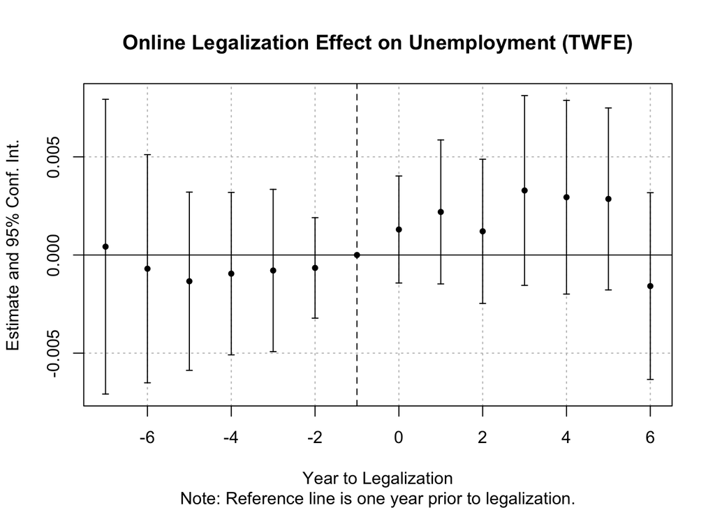

```r
iplot(model_twfe2, main = "Online Legalization Effect on Unemployment (TWFE)", xlab = "Year to Legalization", sub = "Note: Reference line is one year prior to legalization.")
```

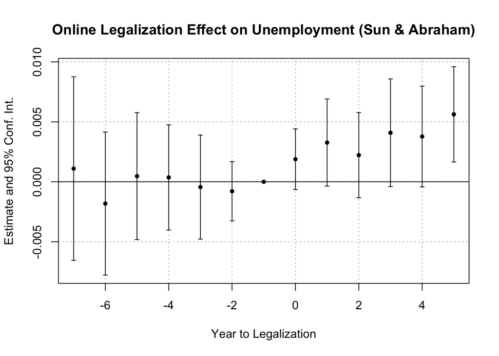

```r
iplot(model_sa2, main = "Online Legalization Effect on Unemployment (Sun & Abraham)", xlab = "Year to Legalization")
```

```r
agg_cohort_sa1 <- aggregate(model_sa1, agg = c("cohort"))
agg_ATT_sa1 <- aggregate(model_sa1, agg = "ATT", use_weights = T)
agg_cohort_sa2 <- aggregate(model_sa2, agg = c("cohort"))
agg_ATT_sa2 <- aggregate(model_sa2, agg = "ATT", use_weights = T)
```

```r
#stargazer()
```

## Employment vs Unemployment Levels Test

Oh very interesting, it seems like employment does go down.

Will have to do

```r
model_sa1_e <- feols(Employment ~ sunab((retailyear), date) +
                      population + rgdp_2017 + bachelors + Poverty.Rate  | abbrev + date,
                    cluster = ~ abbrev,
                    data = df_analysis)
```

```
## NOTE: 112 observations removed because of NA values (RHS: 112).
```

```
## The variables 'date::3:cohort::2017', 'date::3:cohort::2020',
## 'date::4:cohort::2017', 'date::4:cohort::2019', 'date::5:cohort::2017',
## 'date::5:cohort::2018' and 'date::6:cohort::2017' have been removed because of
## collinearity (see $collin.var).
```

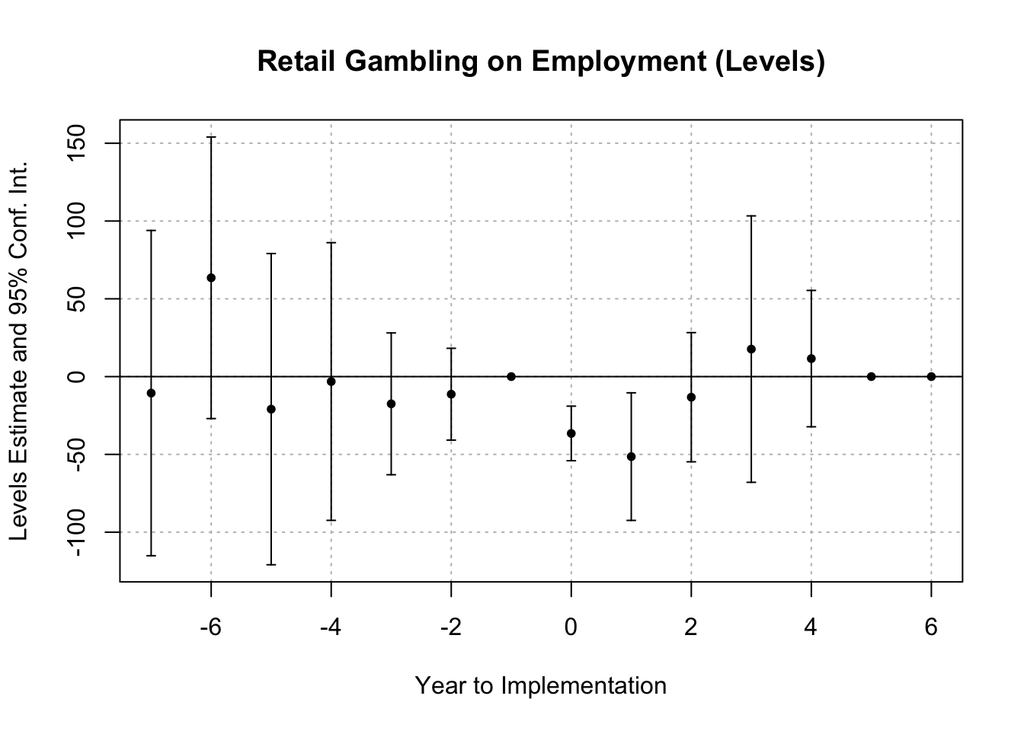

```r
iplot(model_sa1_e, main = "Retail Gambling on Employment (Levels)", xlab = "Year to Implementation", ylab = "Levels Estimate and 95% Conf. Int.")
```

```r
model_sa2_e <- feols(Employment ~ sunab(onlineyear, date) +
                      population + rgdp_2017 + bachelors + Poverty.Rate | abbrev + date,
                    cluster = ~ abbrev,
                    data = df_analysis)
```

```
## NOTE: 153 observations removed because of NA values (RHS: 153).
```

```r
summary(model_sa2_e)
```

```
## OLS estimation, Dep. Var.: Employment
## Observations: 239
## Fixed-effects: abbrev: 30,  date: 8
## Standard-errors: Clustered (abbrev)
##                 Estimate  Std. Error   t value   Pr(>|t|)
## date::-7      -21.516383   43.129856 -0.498874 6.2163e-01
## date::-6       48.948669   54.027990  0.905987 3.7241e-01
## date::-5        0.017993   35.907119  0.000501 9.9960e-01
## date::-4      -10.019318   29.705950 -0.337283 7.3833e-01
## date::-3      -23.446464   29.621391 -0.791538 4.3506e-01
## date::-2       -4.478802   15.243456 -0.293818 7.7099e-01
## date::0       -31.985863   11.331979 -2.822619 8.5168e-03 **
## date::1       -20.568706   17.509933 -1.174688 2.4968e-01
## date::2        11.419289   20.414872  0.559361 5.8021e-01
## date::3        10.546071   14.603966  0.722137 4.7599e-01
## date::4       -24.349658   17.060370 -1.427264 1.6418e-01
## date::5       -11.895395   32.833929 -0.362290 7.1976e-01
## population      0.179218    0.043849  4.087203 3.1556e-04 ***
## rgdp_2017       0.002442    0.000361  6.756983 2.0443e-07 ***
## bachelors    -837.000073 1423.562214 -0.587962 5.6111e-01
## Poverty.Rate -677.378824  578.307602 -1.171312 2.5101e-01
## ---
## Signif. codes:  0 '***' 0.001 '**' 0.01 '*' 0.05 '.' 0.1 ' ' 1
## RMSE: 58.5     Adj. R2: 0.999134
##              Within R2: 0.636287
```

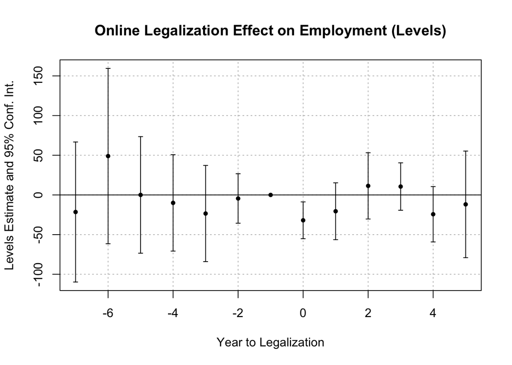

```r
iplot(model_sa2_e, main = "Online Legalization Effect on Employment (Levels)", xlab = "Year to Legalization", ylab = "Levels Estimate and 95% Conf. Int.")
```

```r
par(mfrow = c(1,1))
```

It seems like the unemployment levels data is no good.

```
## NOTE: 112 observations removed because of NA values (RHS: 112).
```

```
## The variables 'date::3:cohort::2017', 'date::3:cohort::2020',
## 'date::4:cohort::2017', 'date::4:cohort::2019', 'date::5:cohort::2017',
## 'date::5:cohort::2018' and 'date::6:cohort::2017' have been removed because of
## collinearity (see $collin.var).
```

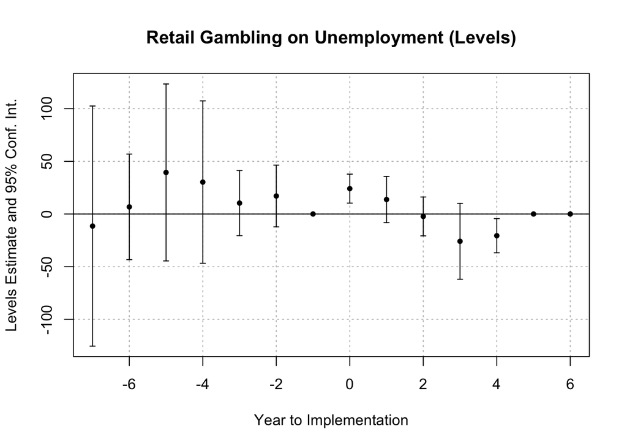

```
## NOTE: 153 observations removed because of NA values (RHS: 153).
```

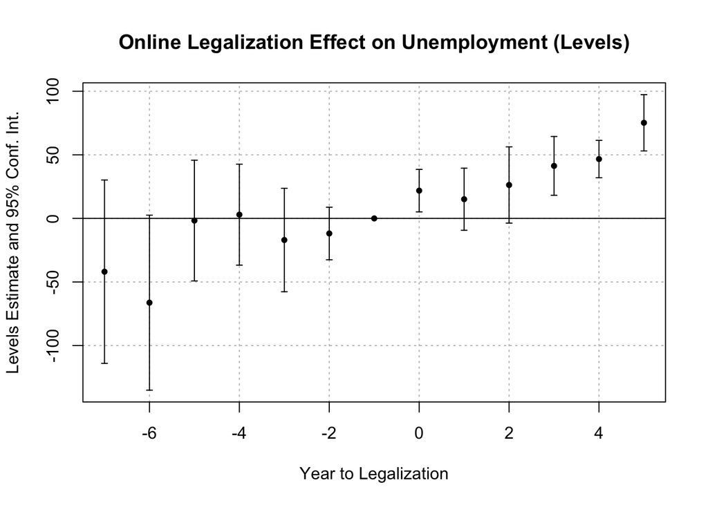

### Poverty Rate…

There is actually no effect, that’s a surprise. Federal minimum wage removed because of collinearity concerns.

```r
model_sa1_pov <- feols(Poverty.Rate ~ sunab(retailyear, date) +
                      population + rgdp_2017 + bachelors + unemployment | abbrev + date,
                    cluster = ~ abbrev,
                    data = df_analysis)
```

```
## NOTE: 112 observations removed because of NA values (RHS: 112).
```

```
## The variables 'date::3:cohort::2017', 'date::3:cohort::2020',
## 'date::4:cohort::2017', 'date::4:cohort::2019', 'date::5:cohort::2017',
## 'date::5:cohort::2018' and 'date::6:cohort::2017' have been removed because of
## collinearity (see $collin.var).
```

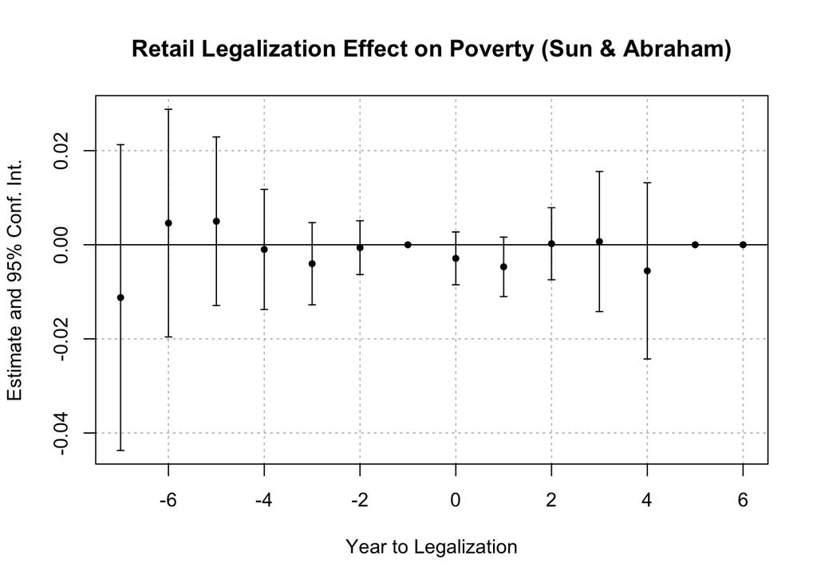

```r
iplot(model_sa1_pov, main = "Retail Legalization Effect on Poverty (Sun & Abraham)", xlab = "Year to Legalization")
```

```r
model_sa2_pov <- feols(Poverty.Rate ~ sunab(onlineyear, date) +
                      population + rgdp_2017 + bachelors + unemployment | abbrev + date,
                    cluster = ~ abbrev,
                    data = df_analysis)
```

```
## NOTE: 153 observations removed because of NA values (RHS: 153).
```

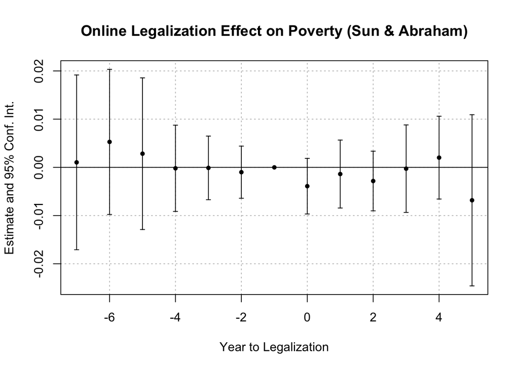

```r
iplot(model_sa2_pov, main = "Online Legalization Effect on Poverty (Sun & Abraham)", xlab = "Year to Legalization")
```

## Three Way DiD with removal of NA mean_eff_rates…

I think the best option here is a correlation analysis in the pre and post trends to see if it is independent. If there is a relationship, then we could make some kind of conjecture of some sort. Otherwise, we just have a table and we compare the results to see if the mean differences and SE are significant.

There’s no relationship whatsoever between the mean effective tax rate and the unemployment rate…

```r
df_analysis2 <- df_analysis %>% na.omit(mean_eff_tax)

summary(df_analysis2)
```

```
##       date         abbrev            population       unemployment
##  Min.   :2018   Length:96          Min.   :  579.6   Min.   :0.02200
##  1st Qu.:2020   Class :character   1st Qu.: 1790.1   1st Qu.:0.03475
##  Median :2021   Mode  :character   Median : 4569.3   Median :0.03900
##  Mean   :2021                      Mean   : 6108.1   Mean   :0.04553
##  3rd Qu.:2023                      3rd Qu.: 8986.4   3rd Qu.:0.05200
##  Max.   :2023                      Max.   :20105.2   Max.   :0.10100
##    bachelors        rgdp_2017          state               legal
##  Min.   :0.2110   Min.   :  37132   Length:96          Min.   :1
##  1st Qu.:0.3035   1st Qu.:  88572   Class :character   1st Qu.:1
##  Median :0.3545   Median : 265895   Mode  :character   Median :1
##  Mean   :0.3497   Mean   : 402667                      Mean   :1
##  3rd Qu.:0.4020   3rd Qu.: 584662                      3rd Qu.:1
##  Max.   :0.4780   Max.   :1791211                      Max.   :1
##    legal.year     retailyear     onlineyear       online      retail
##  Min.   :2013   Min.   :2017   Min.   :2017   Min.   :1   Min.   :1
##  1st Qu.:2018   1st Qu.:2018   1st Qu.:2019   1st Qu.:1   1st Qu.:1
##  Median :2019   Median :2019   Median :2019   Median :1   Median :1
##  Mean   :2019   Mean   :2019   Mean   :2020   Mean   :1   Mean   :1
##  3rd Qu.:2019   3rd Qu.:2020   3rd Qu.:2021   3rd Qu.:1   3rd Qu.:1
##  Max.   :2023   Max.   :2023   Max.   :2023   Max.   :1   Max.   :1
##    tribalonly    notes            mean_eff_tax     Federal.Minimum.Wage
##  Min.   :0    Length:96          Min.   :0.02385   Min.   :7.25
##  1st Qu.:0    Class :character   1st Qu.:0.09447   1st Qu.:7.25
##  Median :0    Mode  :character   Median :0.13683   Median :7.25
##  Mean   :0                       Mean   :0.23103   Mean   :7.25
##  3rd Qu.:0                       3rd Qu.:0.44500   3rd Qu.:7.25
##  Max.   :0                       Max.   :0.68005   Max.   :7.25
##  Governor.is.Democrat..1.Yes. Personal.income    Poverty.Rate
##  Min.   :0.000                Min.   :  40867   Min.   :0.03700
##  1st Qu.:0.000                1st Qu.:  98543   1st Qu.:0.08375
##  Median :1.000                Median : 284672   Median :0.09500
##  Mean   :0.625                Mean   : 399570   Mean   :0.10387
##  3rd Qu.:1.000                3rd Qu.: 600242   3rd Qu.:0.11825
##  Max.   :1.000                Max.   :1557496   Max.   :0.21500
##    state_num     State.Minimum.Wage  Unemployment          year
##  Min.   : 3.00   Min.   : 5.15      Min.   :  8.538   Min.   :2018
##  1st Qu.:14.00   1st Qu.: 7.25      1st Qu.: 39.987   1st Qu.:2020
##  Median :23.00   Median :10.05      Median : 90.418   Median :2021
##  Mean   :25.29   Mean   :10.06      Mean   :149.431   Mean   :2021
##  3rd Qu.:38.25   3rd Qu.:12.05      3rd Qu.:197.085   3rd Qu.:2023
##  Max.   :51.00   Max.   :15.00      Max.   :936.408   Max.   :2023
##    state_fips    SSI.recipients     Employment     time_treat_retail
##  Min.   : 4.00   Min.   :  6.58   Min.   : 275.6   Min.   :0.000
##  1st Qu.:17.00   1st Qu.: 49.28   1st Qu.: 752.6   1st Qu.:1.000
##  Median :26.00   Median : 97.68   Median :2029.4   Median :2.000
##  Mean   :28.27   Mean   :140.16   Mean   :2886.4   Mean   :1.906
##  3rd Qu.:41.25   3rd Qu.:165.82   3rd Qu.:4334.4   3rd Qu.:3.000
##  Max.   :56.00   Max.   :621.78   Max.   :9307.0   Max.   :6.000
##  time_treat_online   time_treat
##  Min.   :-3.000    Min.   : 0.000
##  1st Qu.: 0.000    1st Qu.: 1.000
##  Median : 1.000    Median : 2.000
##  Mean   : 1.458    Mean   : 2.417
##  3rd Qu.: 3.000    3rd Qu.: 4.000
##  Max.   : 6.000    Max.   :10.000
```

```r
eff_tax_1 <- feols(unemployment ~ mean_eff_tax + population + bachelors + rgdp_2017 + Poverty.Rate | abbrev + date(), cluster = ~abbrev, data = df_analysis2)
```

```
## NOTE: 4/0 fixed-effect singletons were removed (4 observations).
```

```r
summary(eff_tax_1)
```

```
## OLS estimation, Dep. Var.: unemployment
## Observations: 92
## Fixed-effects: abbrev: 21,  date(): 1
## Standard-errors: Clustered (abbrev)
##                  Estimate Std. Error   t value   Pr(>|t|)
## mean_eff_tax  0.022931607 0.02294431  0.999446 0.32951797
## population    0.000058607 0.00001240  4.727663 0.00012888 ***
## bachelors     0.102101495 0.07818697  1.305863 0.20642052
## rgdp_2017    -0.000000662 0.00000101 -0.659061 0.51737365
## Poverty.Rate  0.068138916 0.11115472  0.613010 0.54677834
## ---
## Signif. codes:  0 '***' 0.001 '**' 0.01 '*' 0.05 '.' 0.1 ' ' 1
## RMSE: 0.011452     Adj. R2: 0.463515
##                  Within R2: 0.502339
```

```r
eff_tax_2 <- feols(Employment ~ mean_eff_tax + population + bachelors + rgdp_2017 + Poverty.Rate | abbrev + date(), cluster = ~abbrev, data = df_analysis2)
```

```
## NOTE: 4/0 fixed-effect singletons were removed (4 observations).
```

```r
summary(eff_tax_2)
```

```
## OLS estimation, Dep. Var.: Employment
## Observations: 92
## Fixed-effects: abbrev: 21,  date(): 1
## Standard-errors: Clustered (abbrev)
##                 Estimate Std. Error   t value   Pr(>|t|)
## mean_eff_tax  -50.333084  42.437393 -1.186055 2.4950e-01
## population     -0.148395   0.164976 -0.899493 3.7909e-01
## bachelors    -775.498770 590.611596 -1.313044 2.0404e-01
## rgdp_2017       0.005430   0.000675  8.042929 1.0731e-07 ***
## Poverty.Rate   27.457831 358.624330  0.076564 9.3973e-01
## ---
## Signif. codes:  0 '***' 0.001 '**' 0.01 '*' 0.05 '.' 0.1 ' ' 1
## RMSE: 43.9     Adj. R2: 0.999507
##              Within R2: 0.805888
```

```r
# stargazer(summary(eff_tax_1), title = "Effective Tax Rate on Unemployment Rate")
```

This is a much smaller sample though, so must be taken with a grain of salt.

## Supplemental Analysis

We look at credit card debt per capita. I will have to retool the models a little bit given the new variables and all of that…

```r
library(readxl)
credit_debt <- read_excel("/Users/kevinphan981/Programming/ECON427/final_project/other_data/debt_by_state.xlsx",
    sheet = "creditcard", skip = 8)

credit_debt <- credit_debt %>%
  pivot_longer(
    cols = Q4_2003:Q4_2024,
    names_to = c("year"),
    values_to = "debt") %>%
  mutate(year = as.numeric(substring(year, 4, 10))) %>%
  rename("abbrev" = "state",
         "date" = "year")

df_debt <- merge(df_analysis, credit_debt, by = c("date", "abbrev"))
```

```r
credit_delinq <- read_excel("/Users/kevinphan981/Programming/ECON427/final_project/other_data/debt_by_state.xlsx",
    sheet = "creditcard_delinq", skip = 8)

credit_delinq <- credit_delinq %>%
  pivot_longer(
    cols = Q4_2003:Q4_2024,
    names_to = c("year"),
    values_to = "delinq") %>%
  mutate(year = as.numeric(substring(year, 4, 10))) %>%
  rename("abbrev" = "state",
         "date" = "year")

df_delinq <- merge(df_analysis, credit_delinq, by = c("date", "abbrev"))
```

```r
# hmm, if you have fixed effects for state and time, then it fails...

df_debt %>%
  feols((debt) ~ sunab(legal.year, date) + population + rgdp_2017 + bachelors | abbrev + date, clusters = ~abbrev, data = .) -> model_debt
```

```
## NOTE: 96 observations removed because of NA values (RHS: 96).
```

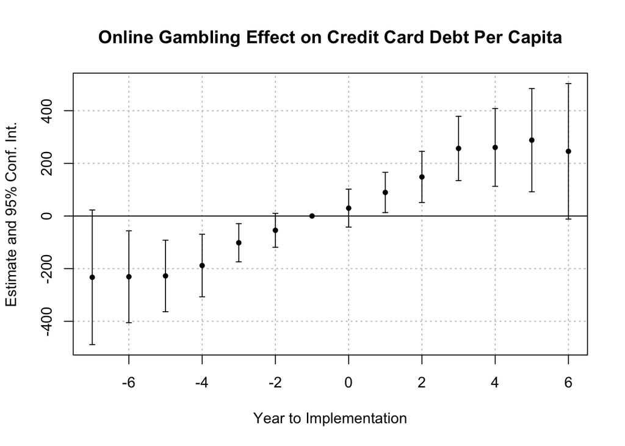

```r
iplot(model_debt, main = "Online Gambling Effect on Credit Card Debt Per Capita",
      xlab = "Year to Implementation")
```

```r
df_debt %>%
  feols((debt) ~ sunab(retailyear, date) + population + rgdp_2017 + bachelors | abbrev + date, clusters = ~abbrev, data = .) -> model_debt_r
```

```
## NOTE: 112 observations removed because of NA values (RHS: 112).
```

```
## The variables 'date::3:cohort::2017', 'date::3:cohort::2020',
## 'date::4:cohort::2017', 'date::4:cohort::2019', 'date::5:cohort::2017',
## 'date::5:cohort::2018' and 'date::6:cohort::2017' have been removed because of
## collinearity (see $collin.var).
```

```r
summary(model_debt_r)
```

```
## OLS estimation, Dep. Var.: debt
## Observations: 280
## Fixed-effects: abbrev: 35,  date: 8
## Standard-errors: IID
##                Estimate Std. Error   t value   Pr(>|t|)
## date::-7     107.057366  86.997332  1.230582 0.21997685
## date::-6     121.126851  79.883453  1.516295 0.13108102
## date::-5      93.212637  57.566449  1.619218 0.10703325
## date::-4      94.395880  47.534814  1.985826 0.04846826 *
## date::-3      42.123207  28.436532  1.481306 0.14015578
## date::-2      30.071199  25.755233  1.167576 0.24441814
## date::0      -21.701643  21.418088 -1.013239 0.31221456
## date::1      -45.051459  28.153562 -1.600205 0.11118885
## date::2      -39.623259  27.013215 -1.466810 0.14405524
## date::3      -94.667768  65.728143 -1.440293 0.15140479
## date::4      -74.738644  80.032859 -0.933849 0.35154840
## population     0.061921   0.053764  1.151731 0.25085626
## rgdp_2017      0.001103   0.000329  3.355275 0.00095462 ***
## bachelors  -1409.681948 883.311606 -1.595906 0.11214599
## ... 7 variables were removed because of collinearity
## (date::3:cohort::2017, date::3:cohort::2020 and 5 others [full set in
## $collin.var])
## ---
## Signif. codes:  0 '***' 0.001 '**' 0.01 '*' 0.05 '.' 0.1 ' ' 1
## RMSE: 57.5     Adj. R2: 0.985031
##              Within R2: 0.255438
```

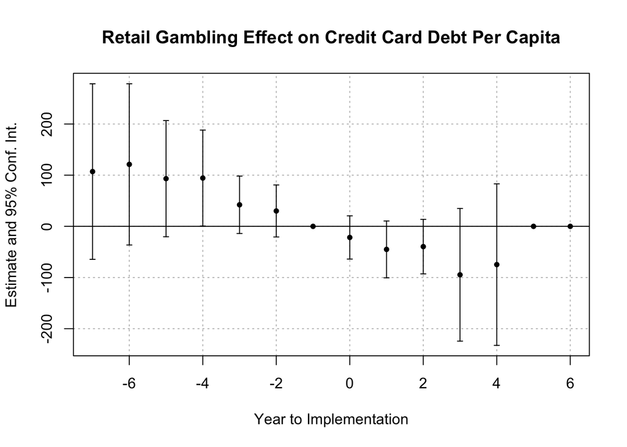

```r
iplot(model_debt_r, main = "Retail Gambling Effect on Credit Card Debt Per Capita", xlab = "Year to Implementation")
```

```r
df_debt %>%
  feols((debt) ~ sunab(onlineyear, date) + population + rgdp_2017 + bachelors | abbrev + date, clusters = ~abbrev, data = .) -> model_debt_o
```

```
## NOTE: 153 observations removed because of NA values (RHS: 153).
```

```r
summary(model_debt_o)
```

```
## OLS estimation, Dep. Var.: debt
## Observations: 239
## Fixed-effects: abbrev: 30,  date: 8
## Standard-errors: IID
##               Estimate Std. Error   t value Pr(>|t|)
## date::-7     17.899385 106.955127  0.167354 0.867307
## date::-6    -19.757447  78.016983 -0.253245 0.800410
## date::-5     -6.922460  63.532462 -0.108959 0.913374
## date::-4     -5.511750  52.178184 -0.105633 0.916008
## date::-3      0.831651  33.755065  0.024638 0.980375
## date::-2     -1.854968  28.374121 -0.065375 0.947958
## date::0       2.793946  28.372884  0.098472 0.921683
## date::1       4.730514  37.356556  0.126631 0.899394
## date::2      26.286514  49.825329  0.527573 0.598540
## date::3      14.594636  65.397396  0.223168 0.823695
## date::4      48.140200  77.289287  0.622857 0.534282
## date::5     106.231606 109.779709  0.967680 0.334693
## population    0.110032   0.058718  1.873896 0.062803 .
## rgdp_2017     0.000864   0.000359  2.403634 0.017399 *
## bachelors  -870.375798 930.573769 -0.935311 0.351064
## ---
## Signif. codes:  0 '***' 0.001 '**' 0.01 '*' 0.05 '.' 0.1 ' ' 1
## RMSE: 56.2     Adj. R2: 0.984934
##              Within R2: 0.2691
```

```r
etable(list(model_debt_r, model_debt_o), tex = F)
```

```
##                            model 1          model 2
## Dependent Var.:               debt             debt
##
## date = -7            107.1 (87.00)    17.90 (107.0)
## date = -6            121.1 (79.88)   -19.76 (78.02)
## date = -5            93.21 (57.57)   -6.922 (63.53)
## date = -4           94.40* (47.53)   -5.512 (52.18)
## date = -3            42.12 (28.44)   0.8317 (33.76)
## date = -2            30.07 (25.76)   -1.855 (28.37)
## date = 0            -21.70 (21.42)    2.794 (28.37)
## date = 1            -45.05 (28.15)    4.731 (37.36)
## date = 2            -39.62 (27.01)    26.29 (49.83)
## date = 3            -94.67 (65.73)    14.59 (65.40)
## date = 4            -74.74 (80.03)    48.14 (77.29)
## population         0.0619 (0.0538) 0.1100. (0.0587)
## rgdp_2017       0.0011*** (0.0003) 0.0009* (0.0004)
## bachelors         -1,409.7 (883.3)   -870.4 (930.6)
## date = 5                              106.2 (109.8)
## Fixed-Effects:  ------------------ ----------------
## abbrev                         Yes              Yes
## date                           Yes              Yes
## _______________ __________________ ________________
## S.E. type                      IID              IID
## Observations                   280              239
## R2                         0.98965          0.99006
## Within R2                  0.25544          0.26910
## ---
## Signif. codes: 0 '***' 0.001 '**' 0.01 '*' 0.05 '.' 0.1 ' ' 1
```

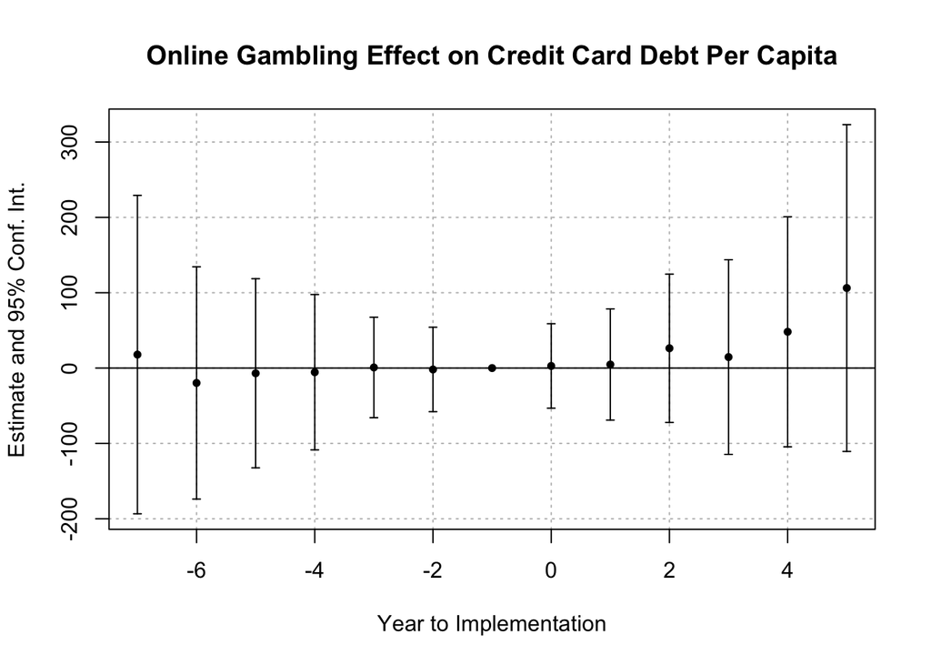

```r
iplot(model_debt_o, main = "Online Gambling Effect on Credit Card Debt Per Capita", xlab = "Year to Implementation")
```

```r
agg_cohort_debtr <- aggregate(model_debt_r, agg = c("cohort"))
agg_ATT_debtr <- aggregate(model_debt_r, agg = "ATT", use_weights = T)

agg_cohort_debto <- aggregate(model_debt_o, agg = c("cohort"))
agg_ATT_debto <- aggregate(model_debt_o, agg = "ATT", use_weights =T)
```

```r
df_delinq %>%
  feols((delinq) ~ sunab(legal.year, date) + population + rgdp_2017 + bachelors | abbrev + date, clusters = ~abbrev, data = .) -> model_delinq
```

```
## NOTE: 96 observations removed because of NA values (RHS: 96).
```

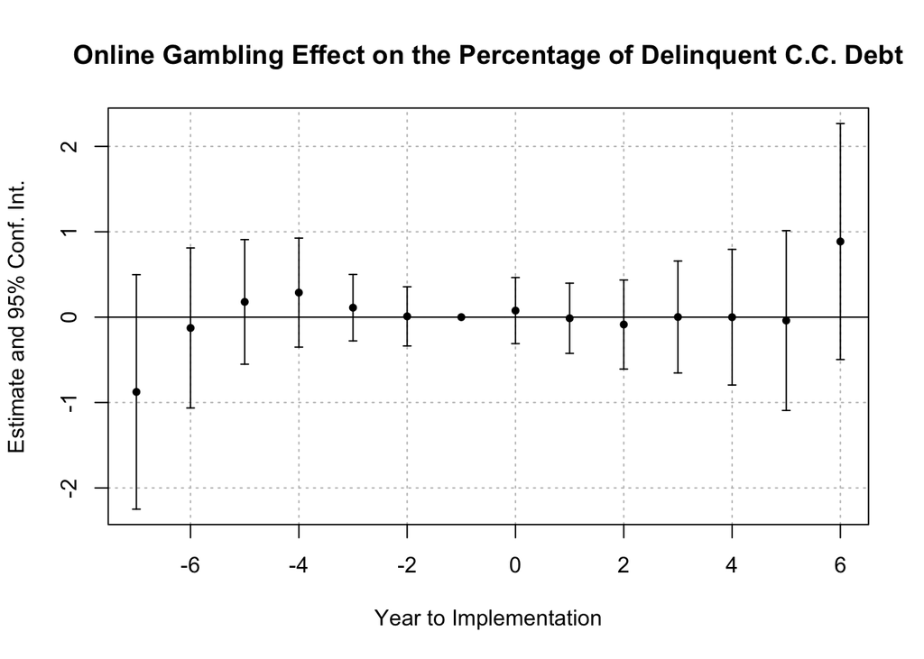

```r
iplot(model_delinq, main = "Online Gambling Effect on the Percentage of Delinquent C.C. Debt", xlab = "Year to Implementation")
```

```r
df_delinq %>%
  feols((delinq) ~ sunab(retailyear, date) + population + rgdp_2017 + bachelors | abbrev + date, clusters = ~abbrev, data = .) -> model_delinq_r
```

```
## NOTE: 112 observations removed because of NA values (RHS: 112).
```

```
## The variables 'date::3:cohort::2017', 'date::3:cohort::2020',
## 'date::4:cohort::2017', 'date::4:cohort::2019', 'date::5:cohort::2017',
## 'date::5:cohort::2018' and 'date::6:cohort::2017' have been removed because of
## collinearity (see $collin.var).
```

```r
summary(model_delinq_r)
```

```
## OLS estimation, Dep. Var.: delinq
## Observations: 280
## Fixed-effects: abbrev: 35,  date: 8
## Standard-errors: IID
##               Estimate Std. Error   t value Pr(>|t|)
## date::-7    0.72828177 0.42309857  1.721305 0.086798 .
## date::-6   -0.40365205 0.38850128 -1.038998 0.300106
## date::-5    0.01488391 0.27996586  0.053163 0.957657
## date::-4   -0.14327936 0.23117849 -0.619778 0.536135
## date::-3    0.07343945 0.13829684  0.531028 0.596010
## date::-2    0.07876385 0.12525674  0.628819 0.530211
## date::0     0.06816633 0.10416368  0.654416 0.513623
## date::1     0.14843926 0.13692066  1.084126 0.279661
## date::2     0.08937972 0.13137475  0.680342 0.497103
## date::3     0.39474661 0.31965904  1.234899 0.218369
## date::4     0.18329348 0.38922790  0.470916 0.638233
## population  0.00018811 0.00026147  0.719429 0.472747
## rgdp_2017  -0.00000275 0.00000164 -1.675203 0.095514 .
## bachelors  -8.03710909 4.29585451 -1.870899 0.062873 .
## ... 7 variables were removed because of collinearity
## (date::3:cohort::2017, date::3:cohort::2020 and 5 others [full set in
## $collin.var])
## ---
## Signif. codes:  0 '***' 0.001 '**' 0.01 '*' 0.05 '.' 0.1 ' ' 1
## RMSE: 0.279717     Adj. R2: 0.944243
##                  Within R2: 0.211765
```

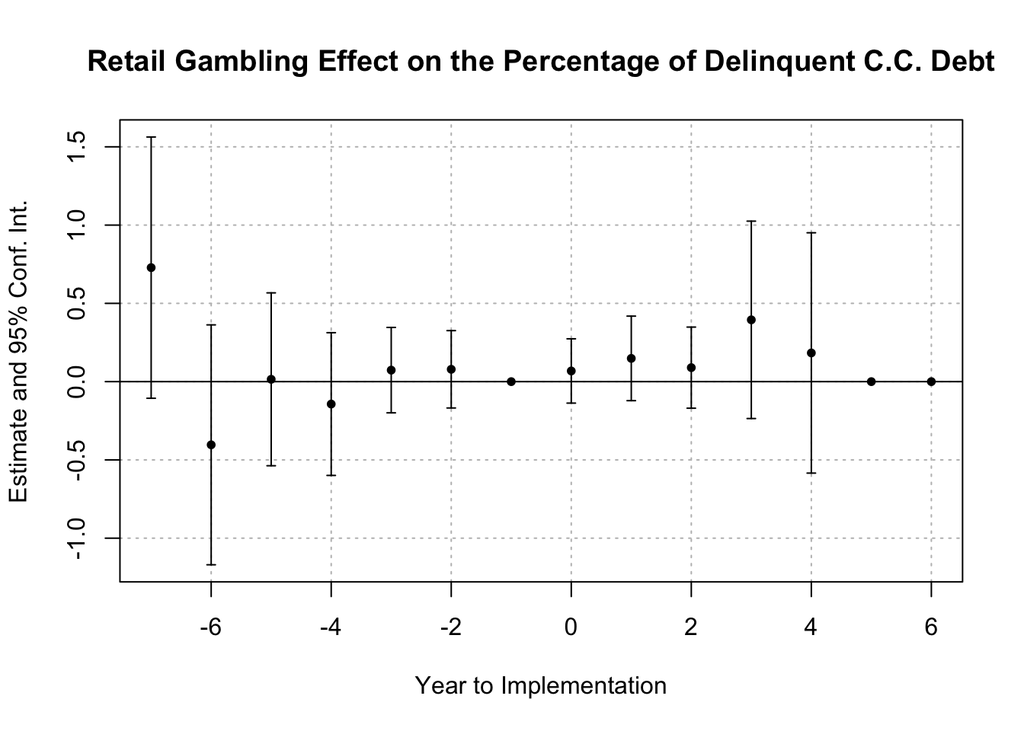

```r
iplot(model_delinq_r, main = "Retail Gambling Effect on the Percentage of Delinquent C.C. Debt", xlab = "Year to Implementation")
```

```r
df_delinq %>%
  feols((delinq) ~ sunab(onlineyear, date) + population + rgdp_2017 + bachelors | abbrev + date, clusters = ~abbrev, data = .) -> model_delinq_o
```

```
## NOTE: 153 observations removed because of NA values (RHS: 153).
```

```r
summary(model_delinq_o)
```

```
## OLS estimation, Dep. Var.: delinq
## Observations: 239
## Fixed-effects: abbrev: 30,  date: 8
## Standard-errors: IID
##               Estimate Std. Error   t value  Pr(>|t|)
## date::-7    0.20407653  0.4963642  0.411143 0.6815286
## date::-6   -0.23017842  0.3620662 -0.635736 0.5258743
## date::-5   -0.18871704  0.2948455 -0.640054 0.5230705
## date::-4   -0.07282849  0.2421519 -0.300755 0.7639989
## date::-3    0.05335233  0.1566527  0.340577 0.7338772
## date::-2    0.02264313  0.1316805  0.171955 0.8636943
## date::0    -0.18661738  0.1316747 -1.417261 0.1583881
## date::1    -0.17631060  0.1733667 -1.016981 0.3107272
## date::2    -0.28273469  0.2312326 -1.222729 0.2232645
## date::3    -0.08600313  0.3035004 -0.283371 0.7772660
## date::4    -0.49859249  0.3586891 -1.390041 0.1664841
## date::5    -0.75200494  0.5094727 -1.476046 0.1419345
## population  0.00058163  0.0002725  2.134375 0.0343646 *
## rgdp_2017  -0.00000491  0.0000017 -2.893786 0.0043479 **
## bachelors  -8.55702204  4.3186666 -1.981404 0.0492922 *
## ---
## Signif. codes:  0 '***' 0.001 '**' 0.01 '*' 0.05 '.' 0.1 ' ' 1
## RMSE: 0.260877     Adj. R2: 0.943492
##                  Within R2: 0.250553
```

```r
etable(list(model_delinq_r, model_delinq_o), tex = F)
```

```
##                             model 1             model 2
## Dependent Var.:              delinq              delinq
##
## date = -7          0.7283. (0.4231)     0.2041 (0.4964)
## date = -6          -0.4037 (0.3885)    -0.2302 (0.3621)
## date = -5           0.0149 (0.2800)    -0.1887 (0.2948)
## date = -4          -0.1433 (0.2312)    -0.0728 (0.2422)
## date = -3           0.0734 (0.1383)     0.0534 (0.1567)
## date = -2           0.0788 (0.1253)     0.0226 (0.1317)
## date = 0            0.0682 (0.1042)    -0.1866 (0.1317)
## date = 1            0.1484 (0.1369)    -0.1763 (0.1734)
## date = 2            0.0894 (0.1314)    -0.2827 (0.2312)
## date = 3            0.3947 (0.3197)    -0.0860 (0.3035)
## date = 4            0.1833 (0.3892)    -0.4986 (0.3587)
## population          0.0002 (0.0003)    0.0006* (0.0003)
## rgdp_2017       -2.75e-6. (1.64e-6) -4.91e-6** (1.7e-6)
## bachelors           -8.037. (4.296)     -8.557* (4.319)
## date = 5                               -0.7520 (0.5095)
## Fixed-Effects:  ------------------- -------------------
## abbrev                          Yes                 Yes
## date                            Yes                 Yes
## _______________ ___________________ ___________________
## S.E. type                       IID                 IID
## Observations                    280                 239
## R2                          0.96143             0.96272
## Within R2                   0.21176             0.25055
## ---
## Signif. codes: 0 '***' 0.001 '**' 0.01 '*' 0.05 '.' 0.1 ' ' 1
```

```r
# cohort average treatment effects and the general ATT
att_labels = c("Retail on Unemployment", "Online on Unemployment", "Retail on Credit Debt", "Online on Credit Debt")

ATT <- rbind(agg_ATT_sa1, agg_ATT_sa2, agg_ATT_debtr, agg_ATT_debto)
stargazer(ATT, title = "ATT from Diff-in-Diff Models", type = "latex", notes = "The ATT is calculated from the CATT using weighted averages. These weighted averages are calculated under the hood when we run Sun and Abraham's estimator using the fixest package in R.")
```

```
##
## % Table created by stargazer v.5.2.3 by Marek Hlavac, Social Policy Institute. E-mail: marek.hlavac at gmail.com
## % Date and time: Mon, Sep 29, 2025 - 22:27:28
## \begin{table}[!htbp] \centering
##   \caption{ATT from Diff-in-Diff Models}
##   \label{}
## \begin{tabular}{@{\extracolsep{5pt}} ccccc}
## \\[-1.8ex]\hline
## \hline \\[-1.8ex]
##  & Estimate & Std. Error & t value & Pr(\textgreater \textbar t\textbar ) \\
## \hline \\[-1.8ex]
## ATT & $0.001$ & $0.001$ & $1.207$ & $0.236$ \\
## ATT.1 & $0.003$ & $0.001$ & $2.714$ & $0.011$ \\
## ATT.2 & $$-$44.126$ & $25.609$ & $$-$1.723$ & $0.086$ \\
## ATT.3 & $18.218$ & $39.157$ & $0.465$ & $0.642$ \\
## \hline \\[-1.8ex]
## \multicolumn{5}{l}{The ATT is calculated from the CATT using weighted averages. These weighted averages are calculated under the hood when we run Sun and Abraham's estimator using the fixest package in R.} \\
## \end{tabular}
## \end{table}
```

```r
cohorts <- as.data.frame(rbind(agg_cohort_sa1, agg_cohort_sa2, agg_cohort_debtr, agg_cohort_debto))
# stargazer(cohorts, main = "Cohort-Level Effects (By Year) By Model") no work

kableExtra::kable(cohorts, type = "text", digits = 3, main = "Cohort-Level Effects (By Year) By Model") %>% kableExtra::kable_classic()
```

|  | Estimate | Std. Error | t value | Pr(>&#124;t&#124;) |
| --- | --- | --- | --- | --- |
| cohort..2017 | 0.011 | 0.004 | 2.457 | 0.019 |
| cohort..2018 | 0.002 | 0.002 | 0.756 | 0.455 |
| cohort..2019 | -0.005 | 0.002 | -3.097 | 0.004 |
| cohort..2020 | -0.006 | 0.002 | -2.423 | 0.021 |
| cohort..2021 | 0.008 | 0.002 | 3.672 | 0.001 |
| cohort..2022 | 0.014 | 0.001 | 14.936 | 0.000 |
| cohort..2023 | 0.003 | 0.002 | 1.324 | 0.194 |
| cohort..2018.1 | 0.002 | 0.002 | 1.200 | 0.240 |
| cohort..2019.1 | 0.000 | 0.001 | 0.079 | 0.937 |
| cohort..2020.1 | 0.008 | 0.003 | 2.685 | 0.012 |
| cohort..2021.1 | 0.005 | 0.004 | 1.268 | 0.215 |
| cohort..2022.1 | 0.004 | 0.004 | 0.991 | 0.330 |
| cohort..2023.1 | 0.001 | 0.001 | 0.440 | 0.663 |
| cohort..2017.1 | -4.778 | 61.177 | -0.078 | 0.938 |
| cohort..2018.2 | -97.435 | 47.796 | -2.039 | 0.043 |
| cohort..2019.2 | -48.634 | 51.749 | -0.940 | 0.348 |
| cohort..2020.2 | -148.688 | 67.085 | -2.216 | 0.028 |
| cohort..2021.2 | 48.606 | 62.651 | 0.776 | 0.439 |
| cohort..2022.2 | -23.363 | 103.962 | -0.225 | 0.822 |
| cohort..2023.2 | 88.516 | 85.065 | 1.041 | 0.299 |
| cohort..2018.3 | 32.160 | 83.808 | 0.384 | 0.702 |
| cohort..2019.3 | 1.041 | 82.302 | 0.013 | 0.990 |
| cohort..2020.3 | -39.023 | 90.621 | -0.431 | 0.667 |
| cohort..2021.3 | 62.127 | 86.931 | 0.715 | 0.476 |
| cohort..2022.3 | 1.544 | 95.029 | 0.016 | 0.987 |
| cohort..2023.3 | 53.317 | 106.230 | 0.502 | 0.616 |